# Assignment 3: Building Features, Watching What Happens

### Are the biggest misses in the least reliable tracts?

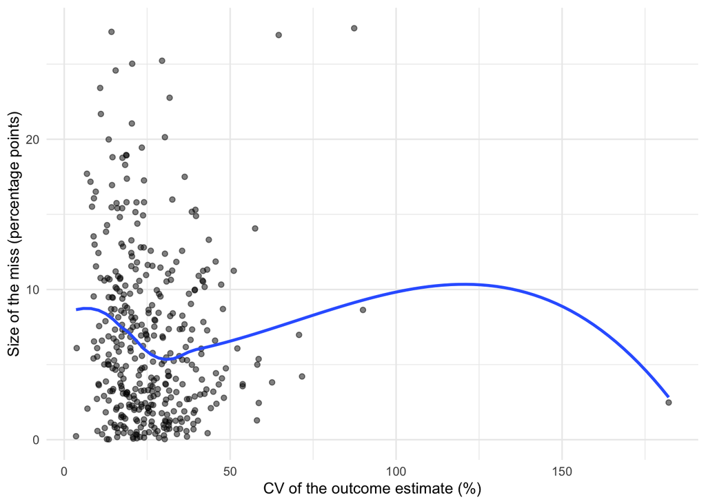

```r
tracts %>%
  filter(is.finite(y_cv)) %>%
  ggplot(aes(x = y_cv, y = abs(resid_final))) +
  geom_point(alpha = 0.5) +
  geom_smooth(se = FALSE) +
  labs(x = "CV of the outcome estimate (%)",
       y = "Size of the miss (percentage points)") +
  theme_minimal()
```

```r
tracts %>%
  st_drop_geometry() %>%
  summarise(
    median_abs_resid = median(abs(resid_final)),
    median_y_moe     = median(y_moe),
    share_within_moe = mean(abs(resid_final) <= y_moe)
  )
```

```
  median_abs_resid median_y_moe share_within_moe
1         5.404462      9.04763        0.7007874
```

## Part 7: Reflection

The feature that helped most was distance to City Hall, which on its own cut the baseline’s error by more than two points. The reason is the one the baseline residual map pointed to: the model knew *who* lived in a tract but not *where*. Income and tenure explain why a household might not afford a car; centrality explains whether it can manage without one. The most disappointing was motor vehicle theft, the only feature that made the model worse on its own. We expected car crime to stand in for car ownership, but in 2023 it mostly measured where Kias and Hyundais were parked. Vehicle crime did eventually earn a place, but only once logged, which says the signal was there and was being drowned out by a few extreme tracts.

Reading one coefficient twice: in the final model, the coefficient on log median income is β̂ = −14.8. As a β̂ reading, a 1% increase in a tract’s median income is associated with about 0.15 percentage points fewer car-free households, holding the other predictors constant. As a ŷ reading, the model predicts that of two otherwise identical tracts, one with a median income of $40,000 and one with $80,000, the richer tract would have about 10.3 percentage points fewer households without a car.

What’s still missing is **transit access**. The red band that survives in North Philadelphia is a set of tracts the model treats like their neighbours, but it appears to follow the Broad Street corridor, where a subway line makes life without a car far easier than distance from City Hall would suggest. Distance to the nearest Indego station is only a partial stand-in. SEPTA publishes its full schedule as GTFS, from which one could count trips per day at stops within a quarter mile of each tract, measuring not just whether transit exists but whether it comes often enough to live on.